# Assignment Four

Gerardo Palacios

1,2

# Covid-19

Pre-processing was necessary in order to tune the plots appropriately. The field names and data types are standardized. In addition, the stringency variable index was binned to represent 4 different stringency levels as opposed to the index value. Finally, the data was summarized and averaged on a weekly basis in order to portray the data in smoothed equal, time intervals. The following visualizations are centered around the relationships between the number of new cases or new deaths and a continents stringency response over the course of the pandemic.

```r
# Import data
data <- read.table("cleandata_rm.csv", header=TRUE, sep=",")

# Convert to date types
data$date <- as.Date(as_date(data$date,format = '%Y-%m-%d'))

# Remove special characters
data$continent <- gsub("\n"," " , data$continent ,ignore.case = TRUE)

data <- data %>% mutate_if(is.character,as.factor)

# Bin the stringency index into 4 parts
data$stry_index <- as.factor(ifelse(
  data$stry_index <= 25, 'No Response' , ifelse(
   data$stry_index > 25 & data$stry_index <= 50 , 'Least Stringent', ifelse(
    data$stry_index > 50 & data$stry_index <= 75 ,'Moderately Stringent',ifelse(
     data$stry_index > 75 ,  'Most Stringent','None')))))

# Define mode function
getmode <- function(v) {
   uniqv <- unique(v)
   uniqv[which.max(tabulate(match(v, uniqv)))]
}

# Copy standardized raw data set
data_raw <- data

# Pivot and summarize data by 7 days
data <- data %>% group_by(
  continent=continent,
  date=floor_date(date, "7 days"),

  ) %>%
   summarize(
     location = getmode(location),
     new_cases=mean(new_cases),
     new_deaths=mean(new_deaths),
     stry_index=getmode(stry_index),
     total_deaths=mean(total_deaths),
     total_cases = mean(total_cases),
     month = mean(month),
     population=mean(population))
# Add new date format
data$date2 <- as.POSIXct(as.yearmon(data$date,
                      format = "%Y-%m-%d"),
                      format = "%m-%d-%Y")

# Create new variable
data$deaths_per_cases <- (data$total_deaths/data$total_cases) * 100
data_raw$deaths_per_cases <- (data_raw$total_deaths/data_raw$total_cases) * 100

# Manually apply log base 10 scale
data$new_cases <- log(data$new_cases+1,10)
data$new_deaths <- log(data$new_deaths+1,10)

data_raw$new_cases <- log(data_raw$new_cases+1,10)
data_raw$new_deaths <- log(data_raw$new_deaths+1,10)
```

## Visualization One

In order to achieve the visualization below, the stringency index had to be binned in to 4 levels. Figure 1 is a mosaic plot showing the total proportion of stringency responses by continent. Each continent had varying response levels. Note that Asia and South America had the most stringent response while North America and Europe responded less urgently.

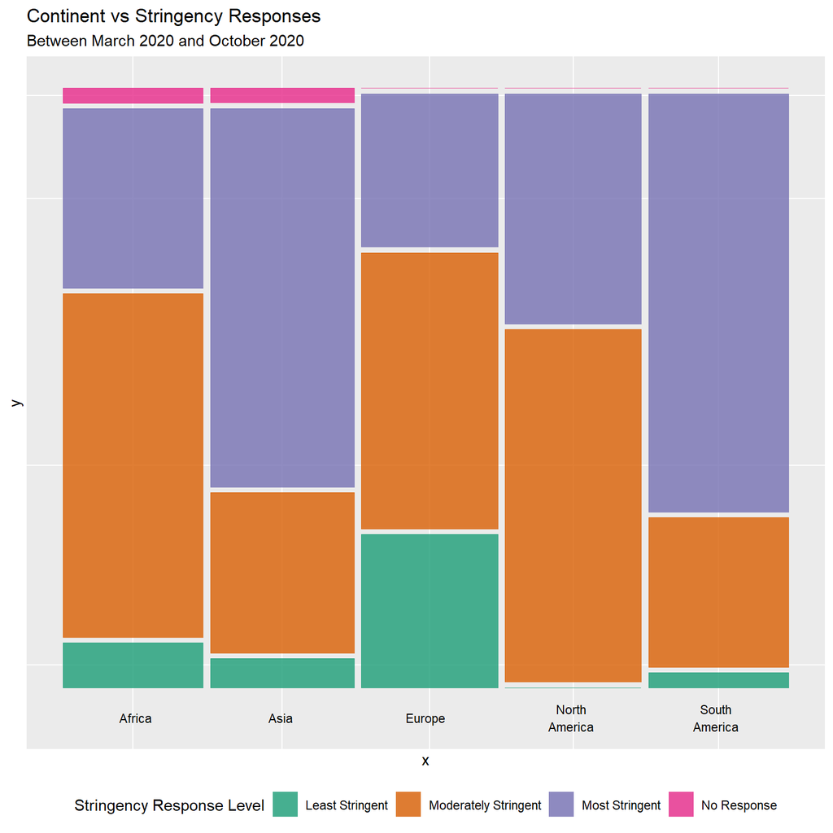

Covid 19 - Stringency Level vs Continent

## Visualization Two

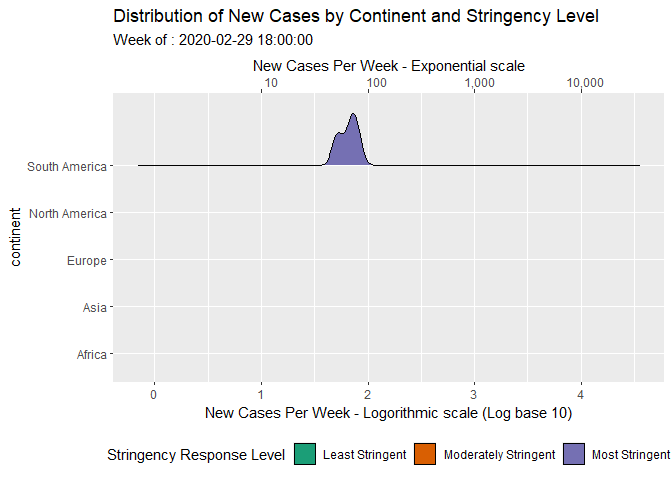

Distributions by Stringency Level and Continent

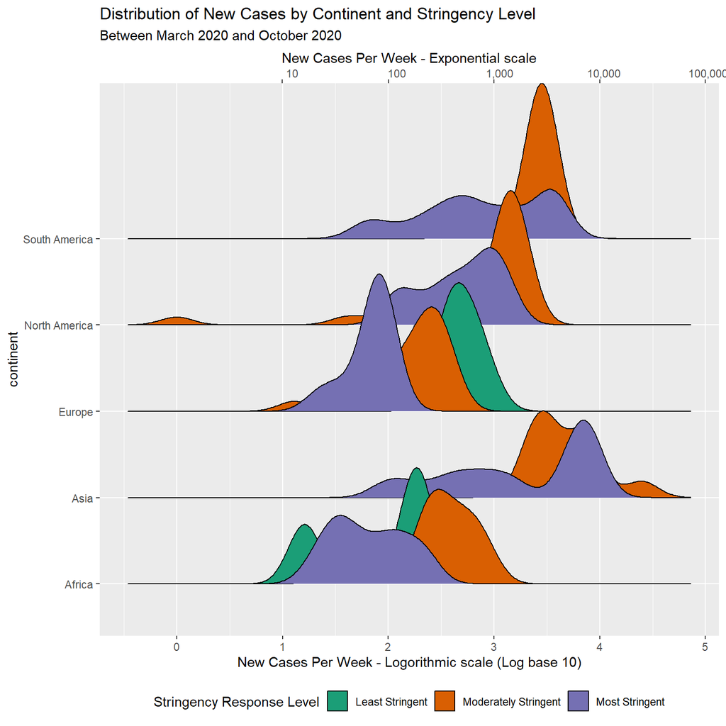

Distributions by Stringency Level and Continent